# APP: UI/UX: Пользовательские интерфейсы и сценарии FoodTracker

Published

June 11, 2026

**WarningОграничение публичной документации**

В открытом доступе представлена **демонстрационная версия** метода. В настоящей публичной документации отображены не все шаги, технические сценарии и приватные эндпоинты для системы цифровых симуляторов бизнес-процессов.

- **Полная спецификация метода:** Будет доступна только во внутреннем контуре разработки (Confluence / Swagger Enterprise).

## 1 Экран «Авторизация и Регистрация» (System Access)

Стартовый экран приложения, предназначенный для аутентификации операторов с помощью идентификатора и ключа доступа.

### 1.1 Визуальные элементы (UI)

- **Верхняя панель управления:**
  - Слева — кнопка переключения языка локализации приложения (на макете: `EN`).
  - Справа — кнопка вызова справочной системы `Help`.
- **Форма авторизации (Центральный блок):**
  - Заголовок формы: Маленький надзаголовок `System Access` и крупное название системы `Food Lifecycle Tracker`.
  - Декоративный элемент: Круглый маркер региона в левом верхнем углу карточки (на макете: `US`).
  - Поле ввода `Operator ID`: Текстовое поле для ввода электронного адреса оператора (в примере: `twin.4@example.com`).
  - Поле ввода `Access Key`: Поле для безопасного ввода пароля/токена (введенные символы маскируются точками).
- **Кнопка действия:** Широкая кнопка `Authorize Session` с синим контуром для отправки учетных данных на сервер.
- **Подвал экрана:** Системная серая надпись по центру: `Digital Business Process Simulators`.

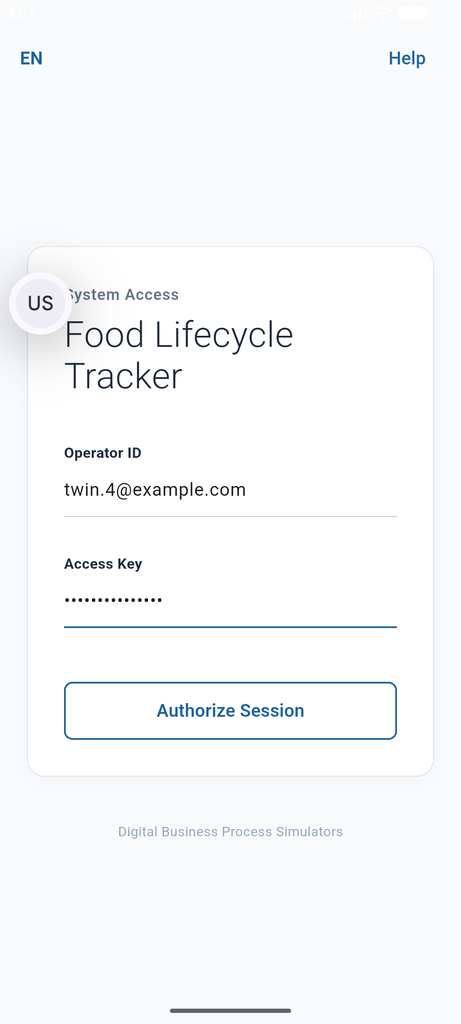

Figure 1: Интерфейс экрана авторизации

### 1.2 Продуктовые сценарии и логика работы

1. **Валидация полей на клиенте:** Кнопка `Authorize Session` блокируется, если поле `Operator ID` не соответствует формату email или поле `Access Key` пустое.
2. **Отправка данных на бэкенд:** При клике на кнопку приложение отправляет введенный email и очищенный пароль доступа в сервис авторизации ( `AuthService`, который мы спроектировали ранее).
3. **Обработка успешного входа:** Если токен активен, приложение сохраняет его локально, перенаправляет пользователя на главный экран «Содержимое холодильника».
4. **Обработка ошибок:** Если введенный email отсутствует в базе или токен отозван, приложение перехватывает ошибку сети (`gRPC 16 / HTTP 401`) и вместо отображения ошибки показывает кастомную шторку например **Access Denied**.

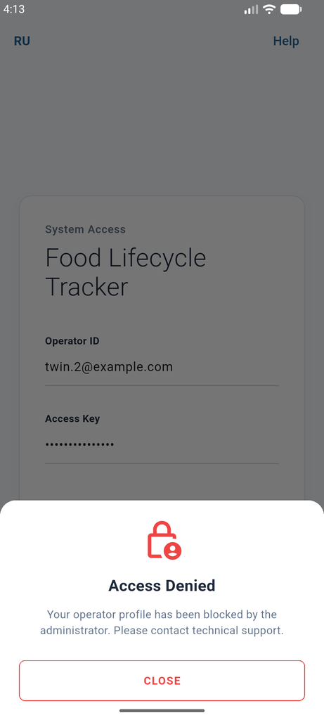

Figure 2: Интерфейс экрана запрета доступа

## 2 Экран «Содержимое холодильника»

Центральный экран приложения, отображающий текущие запасы продуктов пользователя. Предназначен для контроля объемов еды и быстрого перехода к ключевым операциям.

### 2.1 Визуальные элементы (UI)

- **Шапка экрана:**
  - Слева — текстовый заголовок `FRIDGE CONTENT` с синим декоративным маркером.
  - Справа — кнопка `Logout` с иконкой для завершения текущей сессии пользователя.
- **Список продуктов:** Вертикальная лента из карточек. Каждая карточка содержит:
  - Иконку категории продукта (слева).
  - Название продукта крупным шрифтом (например, `Carrot`).
  - Текущий остаток в строке `В наличии:` с одновременным выводом веса в граммах и объема в порциях (например, `700.0 г (2.18 порц.)`).
- **Нижняя панель подсказки:** Текстовая плашка `^ PULL UP TO CHANGE ACTION` со стрелочкой, указывающая на наличие скрытого меню.

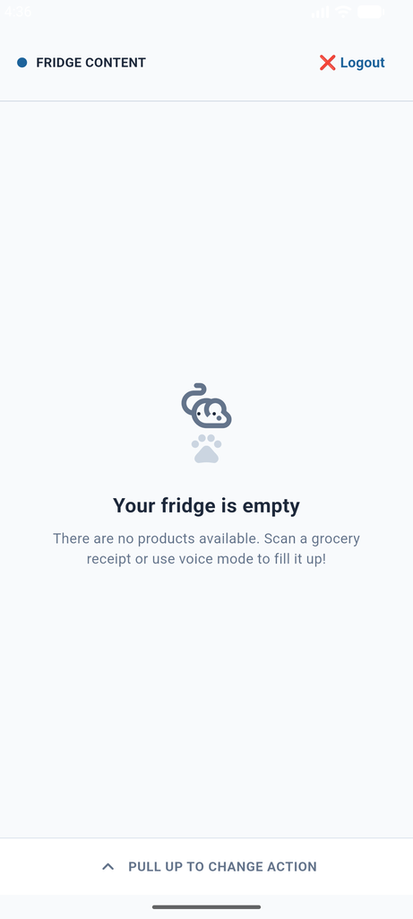

Figure 3: Интерфейс экрана пустого холодильника

### 2.2 Логика работы и сценарии

1. **Загрузка списка:** При открытии экрана приложение запрашивает актуальное содержимое холодильника. Если список пуст, отображается страница-заглушка.
2. **Скроллинг и просмотр:** Пользователь может свободно листать список продуктов вниз и вверх для оценки текущих запасов.
3. **Вызов меню действий:** Потянув нижнюю панель вверх (свайп-жест) или кликнув на нее, пользователь открывает поверх списка шторку выбора действий.

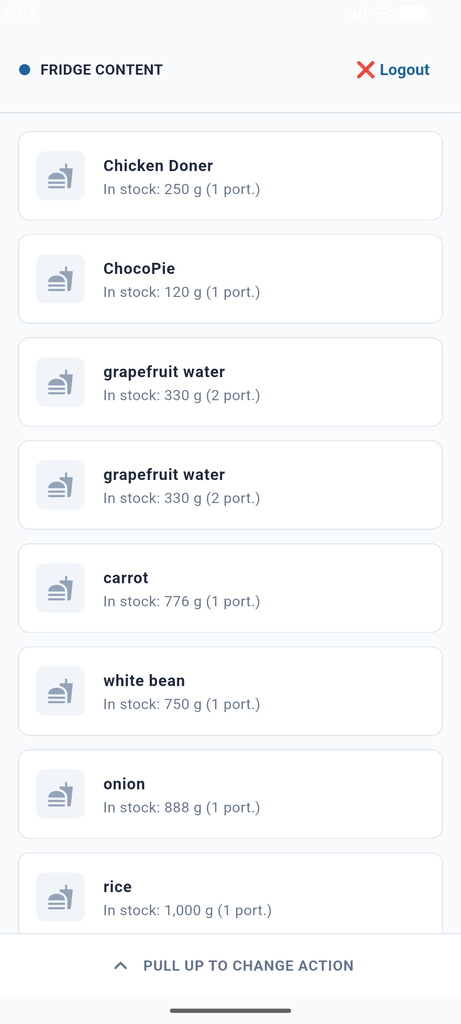

Figure 4: Интерфейс экрана холодильника с продуктами

## 3 Экран «Меню действий» (Шторка)

Всплывающее снизу модальное окно (Bottom Sheet), которое позволяет пользователю зафиксировать то, что он планирует сделать с продуктами прямо сейчас.

### 3.1 Визуальные элементы (UI)

- **Заголовок шторки:** Крупный текст `Выберите действие` в верхней части панели.
- **Основные пункты меню (Действия над текущим списком):**
  - `Просмотр холодильника` (иконка глаза) — закрывает шторку и возвращает к списку.
  - `Списание в мусорку (WASTE)` (иконка корзины) — переход к сценарию утилизации испорченной еды.
  - `Приготовление блюда (COOKING)` (иконка кастрюли с паром) — переход к выбору рецептов или списанию ингредиентов на готовку.
  - `Съел / Потребил (CONSUMPTION)` (иконка вилки и ножа) — переход к фиксации съеденного объема еды.
- **Разделитель:** Горизонтальная серая линия, отделяющая операции изменения текущего холодильника от операций пополнения.
- **Дополнительный пункт:**
  - `Покупка продуктов (PURCHASE)` (иконка корзины для покупок) — выделенный синим цветом пункт для перехода к экрану приёмки новых продуктов (через фото чека, аудио или B2B-магазины).

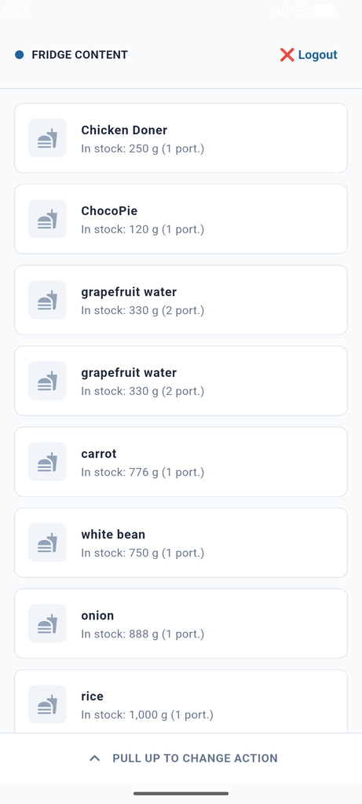

Figure 5: Интерфейс экрана холодильника с продуктами без шторки

### 3.2 Логика работы и сценарии

1. **Затемнение заднего плана:** При появлении шторки основной список продуктов позади нее визуально размывается или затемняется, фокусируя внимание на выборе действия.
2. **Закрытие меню:** Пользователь может закрыть шторку, потянув её вниз или кликнув на пустую область сверху.
3. **Выбор действия:** Нажатие на любой из пунктов меню закрывает шторку и мгновенно перенаправляет пользователя на соответствующий целевой экран (например, на экран камеры при выборе `PURCHASE`).

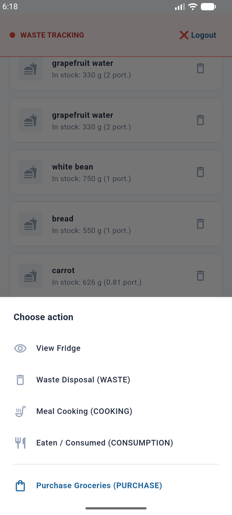

Figure 6: Интерфейс экрана холодильника со шторкой

## 4 Экран «Покупка продуктов» (Режим чека)

Экран предназначен для сканирования печатных чеков или загрузки их фотографий из галереи смартфона для последующего распознавания ИИ-сервисами.

### 4.2 Логика работы и сценарии

1. **Сканирование через камеру:** Пользователь наводит камеру смартфона на чек и тапает по центральной зоне. Приложение начинает покадрово отправлять изображение на бэкенд для распознавания позиций товаров.
2. **Загрузка файла:** Пользователь может нажать нижнюю кнопку, выбрать из медиатеки телефона уже готовый снимок чека и отправить его на сервер.
3. **Отображение статуса:** После успешной отправки файла в облачное хранилище внизу экрана загорается желтая плашка с номером транзакции (ID в S3).

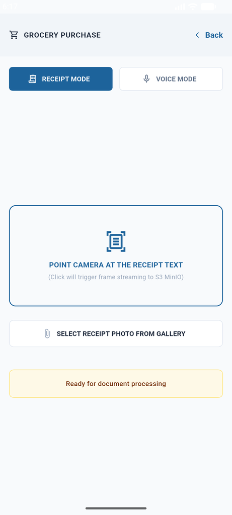

Figure 7: Интерфейс экрана покупки через снимок чека

## 5 Экран «Покупка продуктов» (Режим голоса)

Экран предназначен для быстрого добавления продуктов с помощью голосовых команд (наговаривания списка голосом) или отправки готовых аудиозаписей.

### 5.1 Визуальные элементы (UI)

- **Шапка экрана:** Совпадает с режимом чека (`ПРИЁМКА ПРОДУКТОВ` и кнопка `Назад`).
- **Переключатель режимов (Табы):** Активна правая кнопка `РЕЖИМ ГОЛОСА` (подсвечена синим цветом), левая кнопка чека становится неактивной.
- **Зона записи звука:** Центральный большой элемент в виде зеленого круга с микрофоном и инструкцией `ЗАЖМИТЕ ДЛЯ ЗАПИСИ ГОЛОСА` (Потоковая передача байт буфера микрофона).
- **Кнопка загрузки:** Широкая белая кнопка `ПРИКРЕПИТЬ ГОТОВЫЙ АУДИОФАЙЛ (.WAV)` с иконкой аудио-документа.
- **Информационная плашка:** Дублирует статусную панель с ID транзакции внизу экрана.

### 5.2 Логика работы и сценарии

1. **Голосовой ввод списка:** Пользователь зажимает пальцем большую зеленую кнопку с микрофоном и начинает диктовать список продуктов (например: *«две пачки творога, килограмм томатов»*). Звук в реальном времени стримится на сервер.
2. **Загрузка диктофонной записи:** С помощью нижней кнопки пользователь может выбрать ранее сохраненный на смартфоне файл в формате `.wav` и отправить его на парсинг ИИ.
3. **Результат отправки:** Экран фиксирует успешную доставку аудиофайла на бэкенд и выводит уведомление с ID транзакции для контроля обработки.

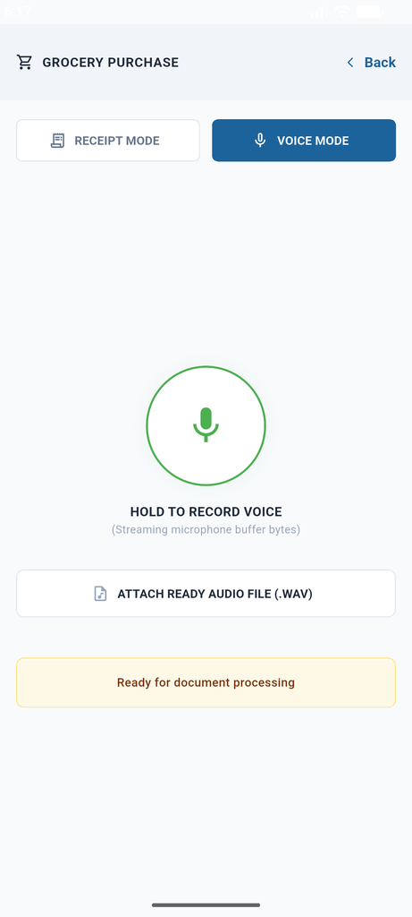

Figure 8: Интерфейс экрана холодильника через голосовое сообщение

## 6 Экран «Готовка»

Экран предназначен для выбора ингредиентов из текущих запасов холодильника, указания их веса и фиксации процесса приготовления нового составного блюда.

### 6.1 Визуальные элементы (UI)

- **Шапка экрана:**
  - Слева — текстовый заголовок `КОНСТРУКТОР БЛЮДА` с иконкой кастрюли с паром.
  - Справа — красная кнопка `Выйти` с крестиком для возврата на главный экран.
- **Верхняя панель параметров:**
  - Поле `Название:` — строка для ручного ввода имени создаваемого блюда (по умолчанию заполнена примером: `Омлет с сыром, Sandwich`).
  - Поле `Порции:` — цифровой счетчик с кнопками плюс `(+)` и минус `(-)` для указания объема готового блюда.
- **Главная кнопка действия:** Широкая кнопка `ПРИГОТОВИТЬ И СМЕНИТЬ` с иконкой вилки и ножа. Динамически отображает количество выбранных позиций, например: `(Выбрано: 0)` или `(Выбрано: 1)`. Если ничего не выбрано, кнопка становится неактивной (серой).
- **Список доступных ингредиентов:** Лента карточек всех продуктов, которые сейчас есть в наличии. На каждой карточке справа расположена кнопка плюс `(+)` для раскрытия параметров.
- **Развернутая карточка продукта (В режиме выбора):** При нажатии на плюс карточка увеличивается в размере и переходит в активный режим:
  - Появляется синяя галочка, подтверждающая выбор.
  - Добавляется блок ввода `Сколько употребить:` с кнопками управления весом и окном ввода значения (например, `50 г`).
- **Нижняя панель подсказки:** Текстовая плашка `^ ТЯНИТЕ ВВЕРХ, ЧТОБЫ СМЕНИТЬ ДЕЙСТВИЕ` для быстрого переключения контекста приложения.

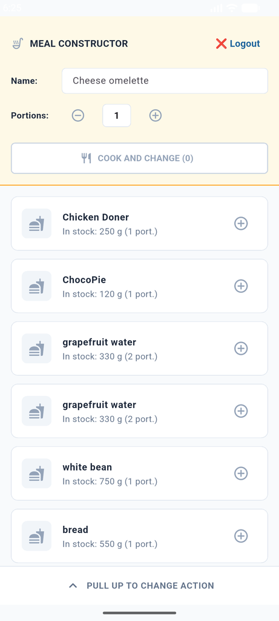

Figure 9: Интерфейс экрана готовки без выбранных продуктов

### 6.2 Логика работы и сценарии

1. **Выбор ингредиентов для блюда:** Пользователь листает список и нажимает на иконку `(+)` напротив нужного продукта (например, тостов). Карточка раскрывается, позволяя указать точный вес, который пойдет в рецепт. Счетчик на главной кнопке автоматически увеличивается на единицу.
2. **Корректировка объемов:** С помощью кнопок `(+)` и `(-)` внутри активной карточки пользователь регулирует граммовку списываемого сырья.
3. **Фиксация готовки:** После ввода названия, указания количества порций и выбора всех ингредиентов пользователь нажимает кнопку `ПРИГОТОВИТЬ И СМЕНИТЬ`. Фронтенд отправляет данные на бэкенд, выбранные продукты частично или полностью списываются, а в холодильнике появляется новая карточка готового блюда.

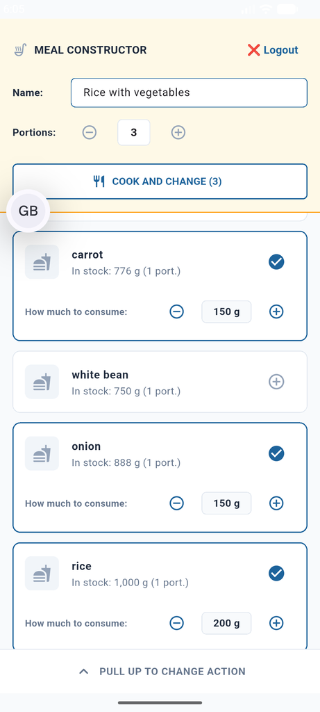

Figure 10: нтерфейс экрана готовки с выбранными продуктами

## 7 Экран «Потребление»

Экран предназначен для фиксации факта приема пищи (потребления). Он позволяет выбрать продукты из холодильника и указать точный вес или объем, который пользователь съел в данный момент.

### 7.1 Визуальные элементы (UI)

- **Шапка экрана:**
  - Слева — текстовый заголовок `КОНСТРУКТОР ПОТРЕБЛЕНИЯ` зеленого цвета с декоративным маркером.
  - Справа — красная кнопка `Выйти` с крестиком для отмены операции и возврата на главный экран.
- **Главная кнопка действия:** Широкая зеленая кнопка `ПОДТВЕРДИТЬ ПОТРЕБЛЕНИЕ`. Динамически отображает количество выбранных для списания позиций, например: `(Выбрано: 1)`. Если ни один продукт не выбран, кнопка блокируется.
- **Список продуктов:** Лента карточек всех имеющихся в наличии запасов. На каждой карточке справа расположена кнопка плюс `(+)` для раскрытия деталей списания.
- **Развернутая карточка продукта (В режиме списания):** При выборе продукта его карточка подсвечивается зеленым контуром и раскрывается:
  - Появляется зеленая круглая галочка, подтверждающая выбор.
  - Добавляется блок ввода `Сколько употребить:` с кнопками уменьшения `(-)` и увеличения `(+)`, а также окном ввода точного веса в граммах (например, `50 г`).
- **Нижняя панель подсказки:** Текстовая плашка `^ ТЯНИТЕ ВВЕРХ, ЧТОБЫ СМЕНИТЬ ДЕЙСТВИЕ` для быстрого переключения между другими режимами приложения.

### 7.2 Логика работы и сценарии

1. **Выбор съеденных продуктов:** Пользователь нажимает на иконку `(+)` на карточке того продукта, который он съел (например, `ХЛЕБ ТОСТОВЫЙ ПШЕНИЧНЫЙ`). Карточка раскрывается, фиксируя выбор, а счетчик на главной кнопке обновляется.
2. **Ввод объема потребления:** Пользователь указывает точный вес съеденной порции с помощью кнопок регулировки или ввода с клавиатуры. При этом приложение визуально подсказывает исходный объем в строке `В наличии` (например, `350.0 г`), чтобы пользователь не ввел значение больше доступного.
3. **Подтверждение списания:** При нажатии кнопки `ПОДТВЕРДИТЬ ПОТРЕБЛЕНИЕ` фронтенд отправляет запрос на бэкенд. Указанный вес вычитается из остатков выбранных продуктов в базе данных, после чего приложение возвращает пользователя к обновленному списку холодильника.

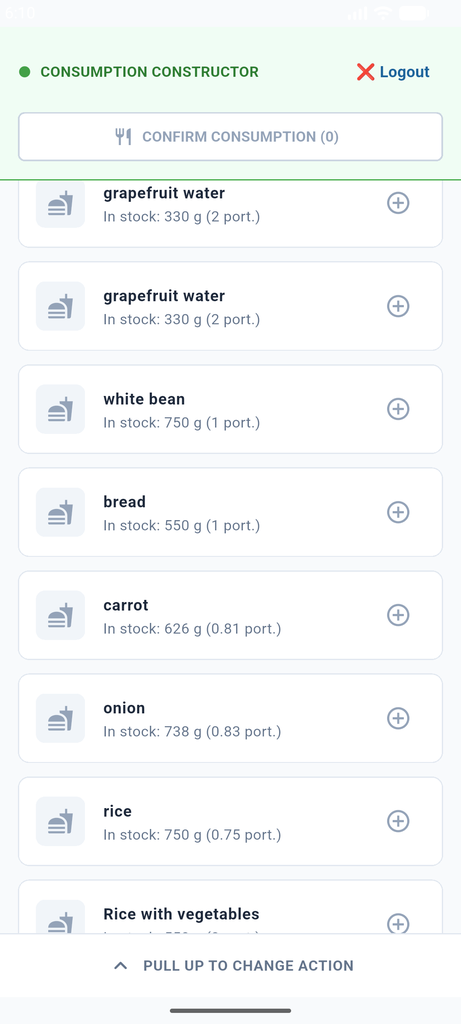

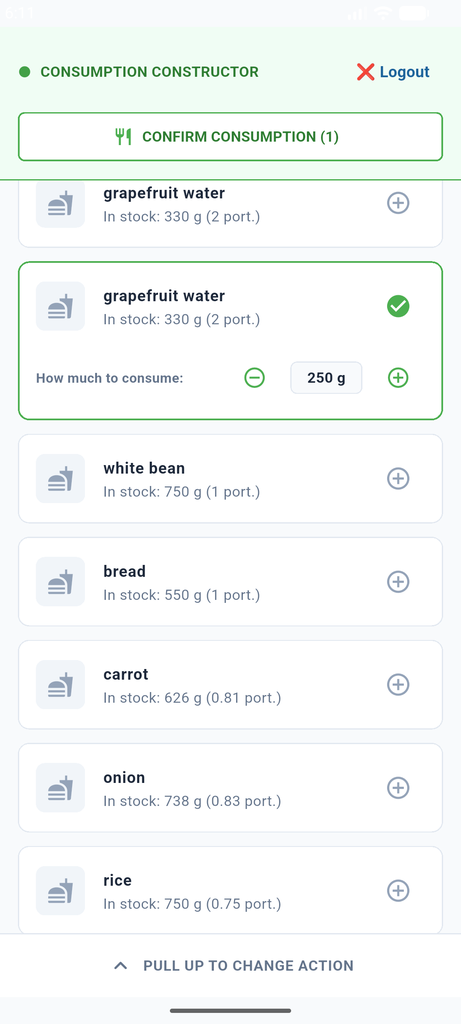

## 8 Экран «Режим: В мусорку (WASTE)»

Экран предназначен для утилизации испорченных продуктов и списания их объемов из системы в мусорку с возможностью указания причины.

### 8.1 Визуальные элементы (UI)

- **Шапка экрана:**
  - Слева — текстовый заголовок `РЕЖИМ: В МУСОРКУ` красного цвета с иконкой бака.
  - Справа — кнопка `Выйти` для отмены режима и возврата к обычному просмотру.
- **Список продуктов для списания:** Лента карточек всех запасов. Справа на каждой карточке вместо плюса отображается серая **иконка мусорного бака**. Клик по ней открывает окно настройки списания.
- **Модальное диалоговое окно «Списание в мусорку»:** Всплывает по центру экрана при выборе конкретного продукта (например, `СЫР СЛИВОЧНЫЙ ТУРЦИЯ`):
  - **Заголовок:** Название выбранного продукта и подзаголовок `Списание в мусорку`.
  - **Быстрые пресеты:** Две кнопки `ВЫБРОСИТЬ ВСЁ` и `ПОЛОВИНУ` для мгновенного заполнения веса.
  - **Регулятор веса:** Счетчик с кнопками уменьшения `(-)` и увеличения `(+)` для ручной настройки веса в граммах (например, `450 г`).
  - **Выпадающий список:** Поле `Причина списания:` с возможностью выбора категории (по умолчанию выставлено `Испортилось`).
  - **Главная кнопка:** Большая ярко-красная кнопка `ПОДТВЕРДИТЬ СПИСАНИЕ`.

### 8.2 Логика работы и сценарии

1. **Выбор объекта утилизации:** Пользователь просматривает список и нажимает на иконку бака напротив продукта, который пришел в негодность. Задний фон затемняется, и открывается модальное окно.
2. **Определение объема утилизации:** Пользователь может в один клик нажать `ВЫБРОСИТЬ ВСЁ` (автоматически подставится максимальный доступный вес из остатков) или `ПОЛОВИНУ`, либо настроить точный вес кнопками шага.
3. **Фиксация причины и отправка:** Пользователь указывает причину (например, продукт испортился, разбился, не понравился вкус) и нажимает кнопку `ПОДТВЕРДИТЬ СПИСАНИЕ`. Фронтенд отправляет данные на бэкенд, баланс продукта в холодильнике уменьшается, а модальное окно закрывается.

### 8.3 Продуктовые сценарии и логические ограничения

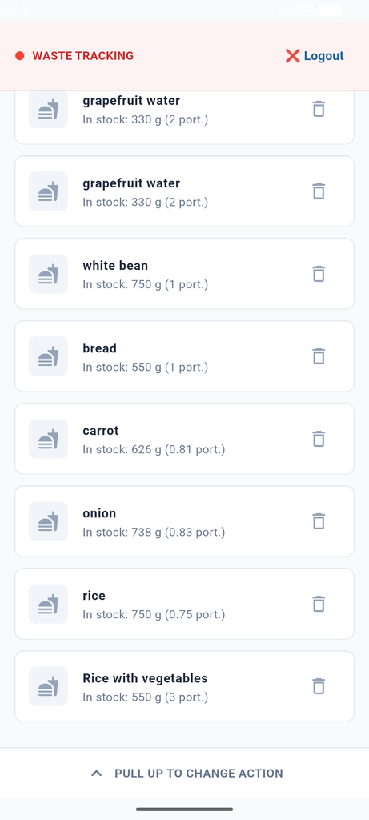

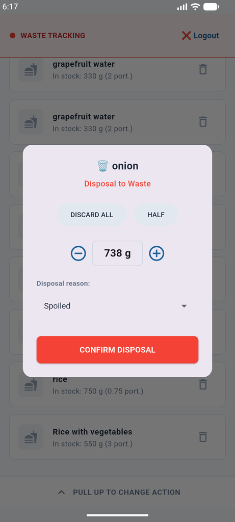

## 9 Связь интерфейса с журналом событий Process Mining (Для аналитиков)

Каждое продуктовое действие на экранах приложения генерирует строгую запись в журнале событий (**Event Log**) на стороне ClickHouse. Данные логи используются для восстановления реального графа процесса, анализа пользовательских путей и поиска узких мест (бутылочных горлышек).

### 9.1 Карта генерации событий (UI to Event Log)

Table 1: : Карта генерации UI-событий и их назначение в аналитике Process Mining

| Элемент интерфейса / Действие пользователя | Генерируемое событие (Activity) | Назначение в Process Mining |
| --- | --- | --- |
| Открытие главного экрана остатков | `Inventory_Viewed` | Метрика начала сессии. Используется для детекции скрытых петель («пассивного просмотра» холодильника). |
| Успешный разбор чека (Камера / Галерея) | `Receipt_OCR_Success` | Фиксация успешного автоматического пополнения запасов. |
| Голосовой ввод / отправка аудиозаписи | `Voice_Parsing_Success` | Фиксация успешного парсинга аудио-команды. |
| Кнопка «ПРИГОТОВИТЬ И СМЕНИТЬ» | `Cooking_Started` | Начало цепочки кулинарной конверсии (трансформация сырья в блюдо). |
| Кнопка «ПОДТВЕРДИТЬ ПОТРЕБЛЕНИЕ» | `Food_Consumed` | Фиксация частичного или полного потребления продукта. |
| Кнопка «ПОДТВЕРДИТЬ СПИСАНИЕ» (WASTE) | `Waste_Dropped` | Фиксация списания испорченной продукции (конечный статус утилизации). |
| Нажатие кнопки «Выйти» из аккаунта | `Session_Finished` | Конечная точка сессии в рамках одного Case ID. |

### 9.2 Обязательный контекст события (Payload лога)

Для проведения качественного анализа процессов, каждое отправляемое с фронтенда событие должно быть обогащено следующими метаданными:

- `case_id` — сквозной идентификатор (связывает сессию пользователя от момента авторизации до закрытия приложения).
- `timestamp` — точное время действия в формате RFC3339 Nano для вычисления точной длительности этапов.
- `user_payload` — дополнительный контекст (например, `store_id` для покупок или `reason` для списания в мусорку).

### 9.3 Хронологический профиль сессии (Пример для Process Mining)

Table 2: : Пример сквозного логирования одной пользовательской сессии в ClickHouse

[output not shown]

```json
{
  "case_id": "SESSION-UUID-2026-1014-4455",
  "timestamp": "2026-10-14T16:05:00.123456789Z",
  "activity": "Waste_Dropped",
  "operator": "twin.4@example.com",
  "user_payload": "{\"product_id\": \"CHEESE-TURKEY-450\", \"weight_grams\": 450, \"reason\": \"Испортилось\"}"
}
```